# Modul_4-Zad_1_Irys_v2

## 1. Analiza danych

[figure not shown]

### 1.1 Kontekst Badania

Analiza danych, znana również jako eksploracyjna analiza danych (EDA), to kompleksowy proces, który obejmuje zastosowanie różnych metod statystycznych w celu zrozumienia struktur i zależności w danych. W ramach analizy danych głównymi cechami są jej wielowymiarowość oraz opisowość, co oznacza, że badanie prowadzi do głębszego wglądu w złożone relacje między zmiennymi. W kontekście francuskim termin „analiza danych” odnosi się do podzbioru statystyki wielowymiarowej, co podkreśla znaczenie złożoności i zróżnicowania, jakie niesie ze sobą ta forma analizy.

### 1.2 Cel Badań

Głównym celem analizy jest porównanie trzech gatunków kwiatów z rodziny Iris, co ma na celu zrozumienie ich różnic morfologicznych oraz rozkładowych cech. Badania ukierunkowane są na następujące gatunki: Iris setosa: Stosunkowo mały i często spotykany, słynący z intensywnych kolorów. Iris versicolor: Cechuje się wieloma wariantami kolorystycznymi oraz bardziej rozłożystymi płatkami. Iris virginica: Przeważnie spotykany w naturalnych siedliskach, często o delikatniejszych kwiatach.

### 1.3 Zestaw Danych

Analiza opiera się na zestawie pomiarów kwiatów irysa, który został udostępniony przez Ronalda Fishera w 1936 roku, stanowiąc jeden z najwcześniejszych przykładów zastosowania analizy statystycznej w botanice. Zbiór zawiera szczegółowe dane dotyczące czterech kluczowych cech morfologicznych, które są istotne dla klasyfikacji różnych gatunków: Długość działki kielicha: Mierzy się ją od podstawy do końca kielicha. Szerokość działki kielicha: Obejmuje pomiary na szerokości w najbardziej wypukłym miejscu kielicha. Długość płatka: Mierzy się od podstawy do końca płatka. Szerokość płatka: Obejmuje szerokość płatka w najszerszym miejscu. Każdy wiersz w zbiorze danych reprezentuje pojedynczy kwiat, a wartości pomiarów są podane w centymetrach, co umożliwia precyzyjne analizy.

### 1.4 Znaczenie Badania

Zbiór danych jest szeroko stosowany w badaniach naukowych jako podstawowy materiał do testowania algorytmów klasyfikacji oraz w kontekście nauki o danych i uczenia maszynowego. Analiza danych z zestawu irysów dostarcza kluczowych informacji na temat różnorodności biologicznej i może być wykorzystana do prognozowania oraz wnioskowania na temat innych gatunków.

### 1.5 Opis Kolumn

- Długość kielicha (sepal length): Reprezentuje długość kielicha w centymetrach, co jest kluczowym parametrem w identyfikacji gatunków.
- Szerokość kielicha (sepal width): Wskazuje na szerokość kielicha, co może wpływać na zdolność kwiatów do przyciągania zapylaczy.
- Długość płatka (petal length): Mierzy, jak długie są płatki, co jest często używane do odróżniania gatunków.
- Szerokość płatka (petal width): Wskazuje na szerokość płatków, co również jest istotne dla klasyfikacji.
- Klasa (class): Określa kategorię, do której należy dany kwiat (setosa, versicolor, virginica), co jest kluczowym elementem w kontekście klasyfikacji.

# 2. Ogólny przegląd danych

#### Przegląd

|  | Długość kielicha | Szerokość kielicha | Długość płatka | Szerokość płatka | gatunek |
| --- | --- | --- | --- | --- | --- |
| 1 | 5.1 | 3.5 | 1.4 | 0.2 | Iris-setosa |
| 2 | 4.9 | 3.0 | 1.4 | 0.2 | Iris-setosa |
| 3 | 4.7 | 3.2 | 1.3 | 0.2 | Iris-setosa |
| 4 | 4.6 | 3.1 | 1.5 | 0.2 | Iris-setosa |
| 5 | 5.0 | 3.6 | 1.4 | 0.2 | Iris-setosa |
| ... | ... | ... | ... | ... | ... |
| 146 | 6.7 | 3.0 | 5.2 | 2.3 | Iris-virginica |
| 147 | 6.3 | 2.5 | 5.0 | 1.9 | Iris-virginica |
| 148 | 6.5 | 3.0 | 5.2 | 2.0 | Iris-virginica |
| 149 | 6.2 | 3.4 | 5.4 | 2.3 | Iris-virginica |
| 150 | 5.9 | 3.0 | 5.1 | 1.8 | Iris-virginica |

150 rows × 5 columns

#### Podstawe informacje o danych zawartych w pliku

```
<class 'pandas.core.frame.DataFrame'>
RangeIndex: 150 entries, 1 to 150
Data columns (total 5 columns):
 #   Column              Non-Null Count  Dtype
---  ------              --------------  -----
 0   Długość kielicha    150 non-null    float64
 1   Szerokość kielicha  150 non-null    float64
 2   Długość płatka      150 non-null    float64
 3   Szerokość płatka    150 non-null    float64
 4   gatunek             150 non-null    object
dtypes: float64(4), object(1)
memory usage: 6.0+ KB
```

#### Sprawdzenie zestawienia pod kątem istnienia wartości brakujących

|  | Długość kielicha | Szerokość kielicha | Długość płatka | Szerokość płatka | gatunek |
| --- | --- | --- | --- | --- | --- |
| 1 | False | False | False | False | False |
| 2 | False | False | False | False | False |
| 3 | False | False | False | False | False |
| 4 | False | False | False | False | False |
| 5 | False | False | False | False | False |
| ... | ... | ... | ... | ... | ... |
| 146 | False | False | False | False | False |
| 147 | False | False | False | False | False |
| 148 | False | False | False | False | False |
| 149 | False | False | False | False | False |
| 150 | False | False | False | False | False |

150 rows × 5 columns

#### Sprawdzenie unikalnych wartości w całym zbiorze danych

```
Długość kielicha      35
Szerokość kielicha    23
Długość płatka        43
Szerokość płatka      22
gatunek                3
dtype: int64
```

#### Sprawdzenie unikalnych wartości w kolumnie gatunek

```
array(['Iris-setosa', 'Iris-versicolor', 'Iris-virginica'], dtype=object)
```

#### Statystyczne podsumowanie kolumn numerycznych dla całego zbioru danych

|  | Długość kielicha | Szerokość kielicha | Długość płatka | Szerokość płatka |
| --- | --- | --- | --- | --- |
| count | 150.000000 | 150.000000 | 150.000000 | 150.000000 |
| mean | 5.843333 | 3.054000 | 3.758667 | 1.198667 |
| std | 0.828066 | 0.433594 | 1.764420 | 0.763161 |
| min | 4.300000 | 2.000000 | 1.000000 | 0.100000 |
| 25% | 5.100000 | 2.800000 | 1.600000 | 0.300000 |
| 50% | 5.800000 | 3.000000 | 4.350000 | 1.300000 |
| 75% | 6.400000 | 3.300000 | 5.100000 | 1.800000 |
| max | 7.900000 | 4.400000 | 6.900000 | 2.500000 |

#### Opis statystyczny zbioru danych z pominięciem ilości wszystkich pozycji - 150

|  | Długość kielicha | Szerokość kielicha | Długość płatka | Szerokość płatka |
| --- | --- | --- | --- | --- |
| mean | 5.843333 | 3.054000 | 3.758667 | 1.198667 |
| std | 0.828066 | 0.433594 | 1.764420 | 0.763161 |
| min | 4.300000 | 2.000000 | 1.000000 | 0.100000 |
| 25% | 5.100000 | 2.800000 | 1.600000 | 0.300000 |
| 50% | 5.800000 | 3.000000 | 4.350000 | 1.300000 |
| 75% | 6.400000 | 3.300000 | 5.100000 | 1.800000 |
| max | 7.900000 | 4.400000 | 6.900000 | 2.500000 |

#### Statystyczne podsumowanie kolumn numerycznych dla poszczególnych gatunków kwiatów z zaznaczeniem wartości minimalnych i maksymalnych

|  | gatunek | Długość kielicha median | Długość kielicha std | Długość kielicha min | Długość kielicha max | Szerokość kielicha median | Szerokość kielicha std | Szerokość kielicha min | Szerokość kielicha max | Długość płatka median | Długość płatka std | Długość płatka min | Długość płatka max | Szerokość płatka median | Szerokość płatka std | Szerokość płatka min | Szerokość płatka max |
| --- | --- | --- | --- | --- | --- | --- | --- | --- | --- | --- | --- | --- | --- | --- | --- | --- | --- |
| 0 | Iris-setosa | 5.000000 | 0.352490 | 4.300000 | 5.800000 | 3.400000 | 0.381024 | 2.300000 | 4.400000 | 1.500000 | 0.173511 | 1.000000 | 1.900000 | 0.200000 | 0.107210 | 0.100000 | 0.600000 |
| 1 | Iris-versicolor | 5.900000 | 0.516171 | 4.900000 | 7.000000 | 2.800000 | 0.313798 | 2.000000 | 3.400000 | 4.350000 | 0.469911 | 3.000000 | 5.100000 | 1.300000 | 0.197753 | 1.000000 | 1.800000 |
| 2 | Iris-virginica | 6.500000 | 0.635880 | 4.900000 | 7.900000 | 3.000000 | 0.322497 | 2.200000 | 3.800000 | 5.550000 | 0.551895 | 4.500000 | 6.900000 | 2.000000 | 0.274650 | 1.400000 | 2.500000 |

# 3. Przedstawienie graficzne danych

#### Porównanie cech dla gatunków

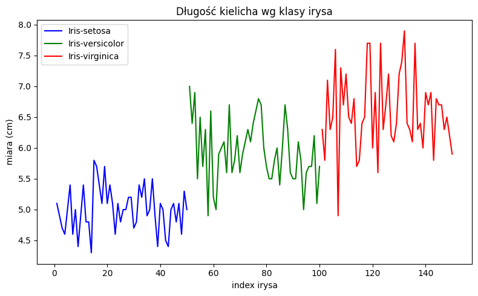

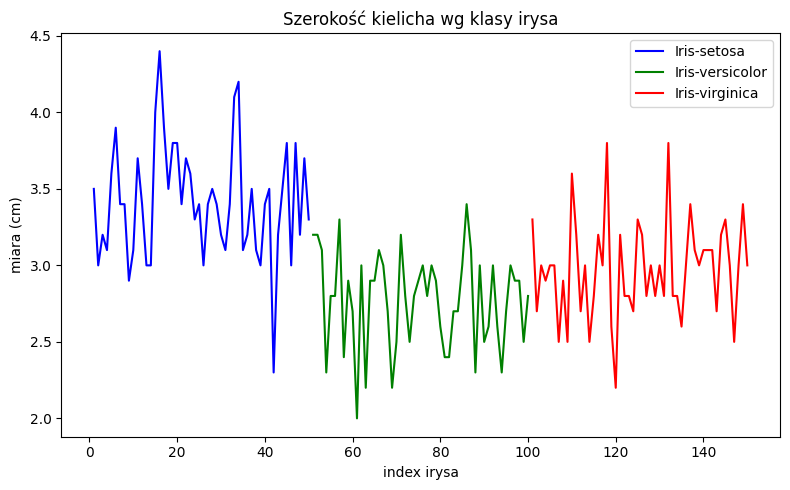

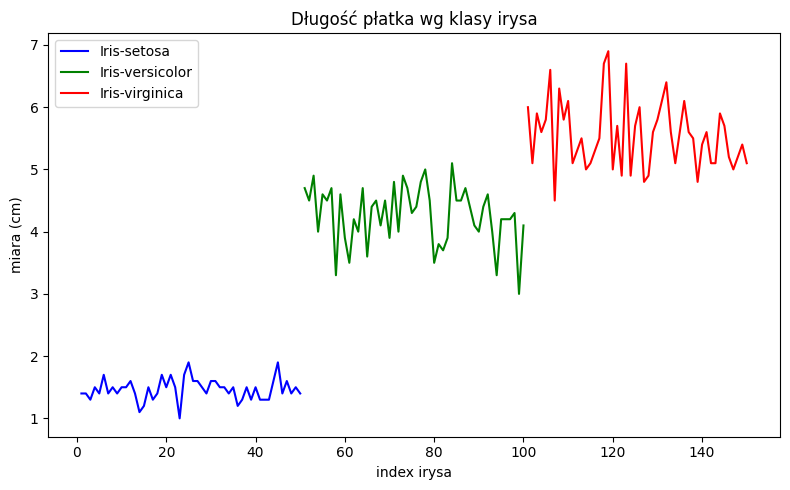

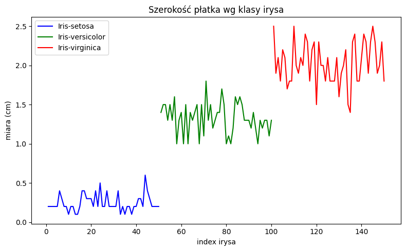

#### Analiza zależności między cechami

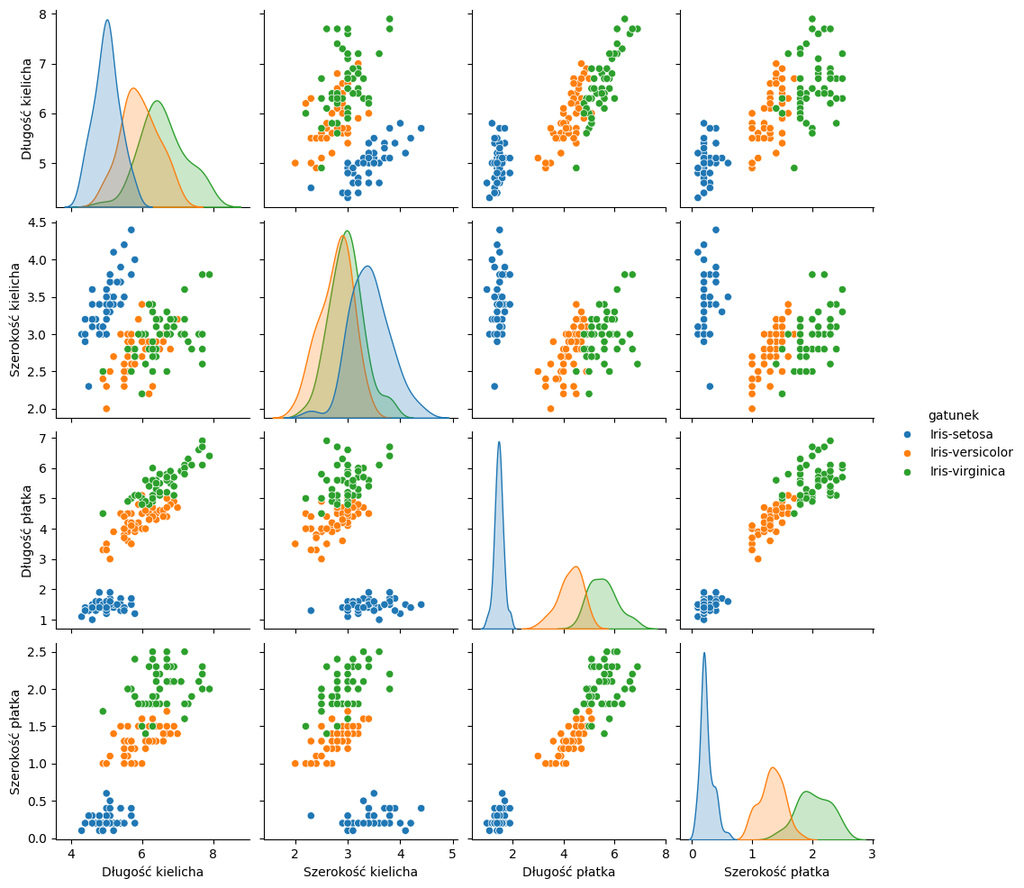

# 4. Wartości odstające (outliers)

#### Wykresy boxplot dla wartrości odstających

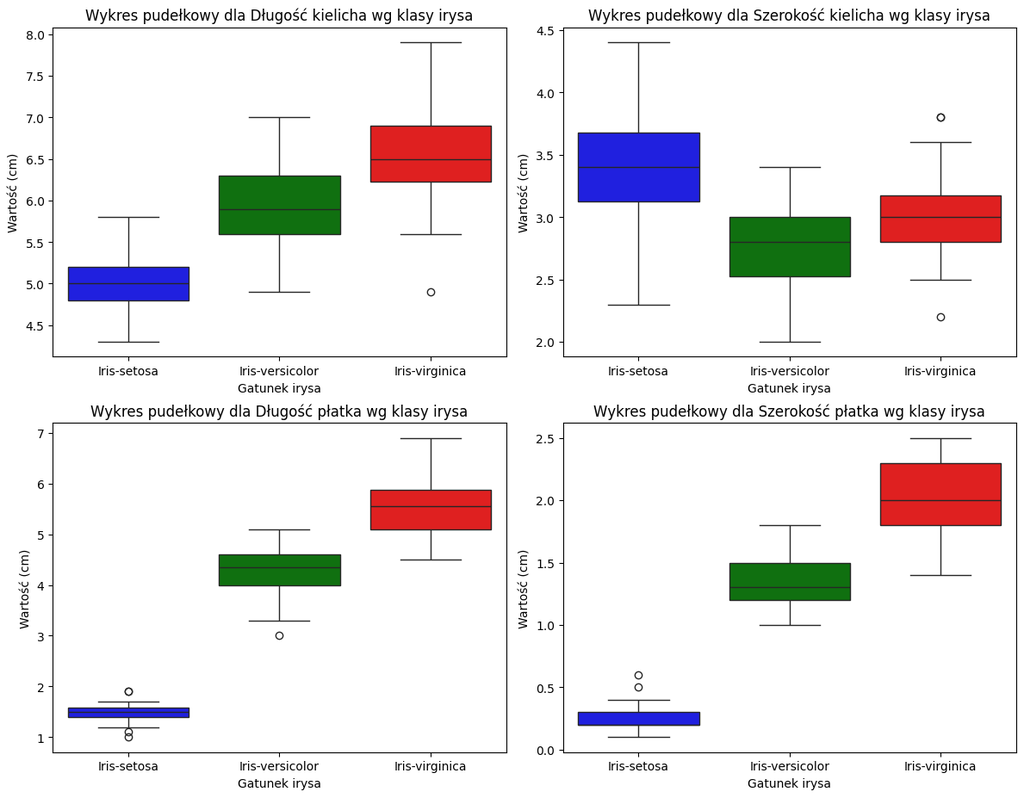

# 5. Podsumowanie

Dane obejmują 150 pomiarów kwiatów irysa, należących do trzech gatunków: Iris setosa, Iris versicolor oraz Iris virginica (po 50 egzemplarzy każdego gatunku).

Iris setosa odróżnia się wyraźnie od pozostałych dwóch gatunków – jego płatki są znacznie krótsze i węższe. Dzięki temu klasyfikacja tego gatunku jest stosunkowo prosta.

Iris versicolor i Iris virginica mają wartości cech częściowo nakładające się. Ich rozróżnienie wymaga dokładniejszych metod statystycznych

Rozkłady długości i szerokości płatków są szczególnie przydatne do rozróżniania gatunków – cechy płatków wykazują większą separację międzygatunkową niż cechy kielicha.

Dane są dobrze zbalansowane (po równo obserwacji dla każdego gatunku), co czyni je idealnym zbiorem do testowania algorytmów klasyfikacyjnych.

#### 6. Szczegółowy przegląd danych

Iris virginica

[figure not shown]

Iris versicolor

[figure not shown]

Iris setosa

[figure not shown]

|  | Długość kielicha | Szerokość kielicha | Długość płatka | Szerokość płatka | gatunek |
| --- | --- | --- | --- | --- | --- |
| 1 | 5.100000 | 3.500000 | 1.400000 | 0.200000 | Iris-setosa |
| 2 | 4.900000 | 3.000000 | 1.400000 | 0.200000 | Iris-setosa |
| 3 | 4.700000 | 3.200000 | 1.300000 | 0.200000 | Iris-setosa |
| 4 | 4.600000 | 3.100000 | 1.500000 | 0.200000 | Iris-setosa |
| 5 | 5.000000 | 3.600000 | 1.400000 | 0.200000 | Iris-setosa |
| 6 | 5.400000 | 3.900000 | 1.700000 | 0.400000 | Iris-setosa |
| 7 | 4.600000 | 3.400000 | 1.400000 | 0.300000 | Iris-setosa |
| 8 | 5.000000 | 3.400000 | 1.500000 | 0.200000 | Iris-setosa |
| 9 | 4.400000 | 2.900000 | 1.400000 | 0.200000 | Iris-setosa |
| 10 | 4.900000 | 3.100000 | 1.500000 | 0.100000 | Iris-setosa |
| 11 | 5.400000 | 3.700000 | 1.500000 | 0.200000 | Iris-setosa |
| 12 | 4.800000 | 3.400000 | 1.600000 | 0.200000 | Iris-setosa |
| 13 | 4.800000 | 3.000000 | 1.400000 | 0.100000 | Iris-setosa |
| 14 | 4.300000 | 3.000000 | 1.100000 | 0.100000 | Iris-setosa |
| 15 | 5.800000 | 4.000000 | 1.200000 | 0.200000 | Iris-setosa |
| 16 | 5.700000 | 4.400000 | 1.500000 | 0.400000 | Iris-setosa |
| 17 | 5.400000 | 3.900000 | 1.300000 | 0.400000 | Iris-setosa |
| 18 | 5.100000 | 3.500000 | 1.400000 | 0.300000 | Iris-setosa |
| 19 | 5.700000 | 3.800000 | 1.700000 | 0.300000 | Iris-setosa |
| 20 | 5.100000 | 3.800000 | 1.500000 | 0.300000 | Iris-setosa |
| 21 | 5.400000 | 3.400000 | 1.700000 | 0.200000 | Iris-setosa |
| 22 | 5.100000 | 3.700000 | 1.500000 | 0.400000 | Iris-setosa |
| 23 | 4.600000 | 3.600000 | 1.000000 | 0.200000 | Iris-setosa |
| 24 | 5.100000 | 3.300000 | 1.700000 | 0.500000 | Iris-setosa |
| 25 | 4.800000 | 3.400000 | 1.900000 | 0.200000 | Iris-setosa |
| 26 | 5.000000 | 3.000000 | 1.600000 | 0.200000 | Iris-setosa |
| 27 | 5.000000 | 3.400000 | 1.600000 | 0.400000 | Iris-setosa |
| 28 | 5.200000 | 3.500000 | 1.500000 | 0.200000 | Iris-setosa |
| 29 | 5.200000 | 3.400000 | 1.400000 | 0.200000 | Iris-setosa |
| 30 | 4.700000 | 3.200000 | 1.600000 | 0.200000 | Iris-setosa |

[output cut: 120 more lines]

[output not shown]

[output not shown]